# Assignment_4_Hanjie WANG

Hanjie WANG

May 25, 2017

Set up

### Bailey 8.2 @Bailey2016a

```r
peacecorp<-read_csv('./Data/PeaceCorpsHW.csv')
```

1. Before looking at the data, I hypotehsize that the unemployrate (state unemployment rate) positively correlates with appspc (Applications to the Peace Corps from each state per capita). Put differently, the higher the unemplyment rate, the more application to the Peace Corps. I hypothesize in this way because I think young people will be glad to seek at least some job experience when jobs are scarce. And Peace Corps offers them both the job opportunity and the opportunity to work abroad and acquire experience.

```r
reg82b<- lm(appspc~unemployrate+factor(year), data=peacecorp)
summary(reg82b)
```

```
##
## Call:
## lm(formula = appspc ~ unemployrate + factor(year), data = peacecorp)
##
## Residuals:
##     Min      1Q  Median      3Q     Max
## -45.967 -20.692  -9.942   6.758 307.491
##
## Coefficients:
##                  Estimate Std. Error t value Pr(>|t|)
## (Intercept)        47.515      9.607   4.946 1.27e-06 ***
## unemployrate        1.107      1.632   0.678    0.498
## factor(year)2007   -5.338      8.987  -0.594    0.553
## factor(year)2008   -0.335      9.101  -0.037    0.971
## factor(year)2009    2.613     11.152   0.234    0.815
## factor(year)2010   -5.004     11.454  -0.437    0.663
## factor(year)2011  -10.388     10.864  -0.956    0.340
## ---
## Signif. codes:  0 '***' 0.001 '**' 0.01 '*' 0.05 '.' 0.1 ' ' 1
##
## Residual standard error: 45.38 on 299 degrees of freedom
## Multiple R-squared:  0.01105,    Adjusted R-squared:  -0.008792
## F-statistic: 0.557 on 6 and 299 DF,  p-value: 0.7644
```

The results suggests that on average, state unemployment rate will increase the peace corps application by 1.107. And each year has different impact on the application. None of the results is statistically significant, hence suggesting we accept the null hypothesis that neither unemployment rate nor year-specific effects have any influence on the application to peace corps. The problem here is that it does differentiate states but take them aggregately. But each states have different economic characteristics and population profile, both of which might influence the unemployment rate. Failing to account for this differences, this pooled regression is problematic.

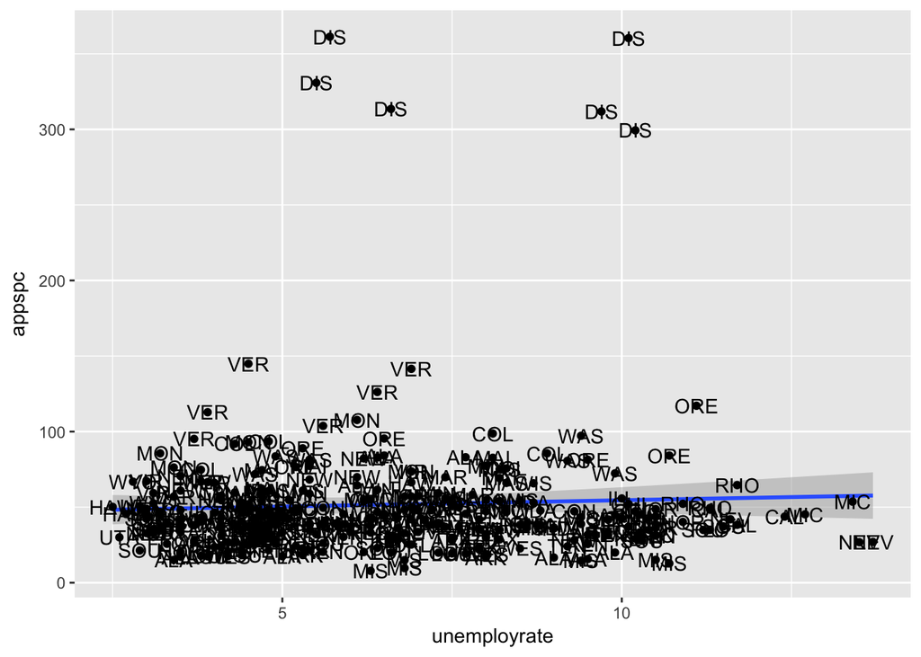

```r
ggplot(data=peacecorp, mapping = aes(x=unemployrate, y=appspc))+
  geom_smooth(method=lm)+
  geom_point()+
  geom_text(aes(label=stateshort))
```

The plot looks ugly, but it clearly suggests that DIS (District of Columbia) is the outlier that the peace corpore application is over 300. (Other seemingly outliers are VER and ORE.) This would bias the estimate on unemployment rate by magnifying it at the same unemployment rate.

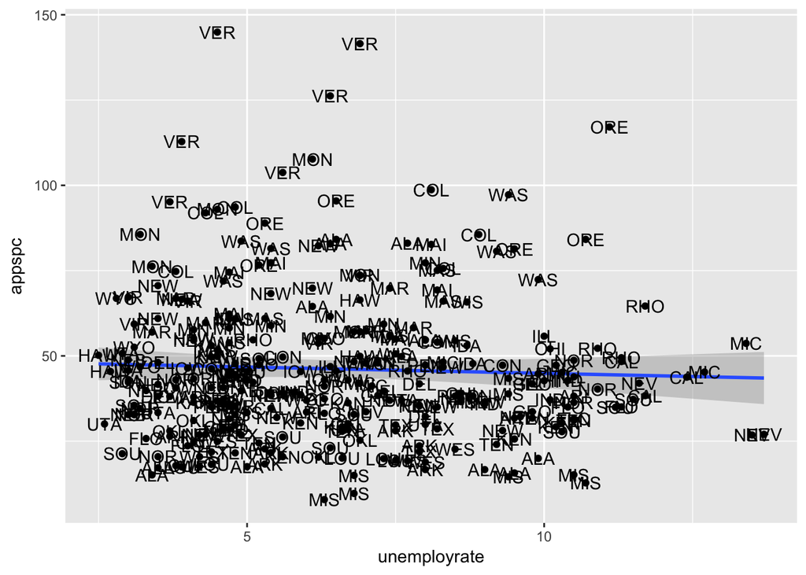

```r
peacecorp_c<- filter(peacecorp, stateshort !="DIS")
ggplot(data=peacecorp_c, mapping = aes(x=unemployrate, y=appspc))+
  geom_smooth(method=lm)+
  geom_point()+
  geom_text(aes(label=stateshort))
```

The second scatterplot takes out the unusual state displays a concentration of points and the regression line gets flatter as the bias of DIC is removed. More specifically, the uprising trend is reversed to a downward trend. Moreover it seems now the observations under VER and ORE are biasing the regression line.

```r
reg82d<- lm(appspc~unemployrate+factor(year), data=peacecorp_c)
summary(reg82d)
```

```
##
## Call:
## lm(formula = appspc ~ unemployrate + factor(year), data = peacecorp_c)
##
## Residuals:
##     Min      1Q  Median      3Q     Max
## -38.022 -13.772  -4.282   9.187  95.559
##
## Coefficients:
##                  Estimate Std. Error t value Pr(>|t|)
## (Intercept)        54.844      4.616  11.881  < 2e-16 ***
## unemployrate       -1.964      0.786  -2.498  0.01304 *
## factor(year)2007   -5.061      4.337  -1.167  0.24418
## factor(year)2008    3.348      4.392   0.762  0.44643
## factor(year)2009   16.173      5.379   3.007  0.00287 **
## factor(year)2010    8.375      5.523   1.516  0.13053
## factor(year)2011    2.183      5.233   0.417  0.67680
## ---
## Signif. codes:  0 '***' 0.001 '**' 0.01 '*' 0.05 '.' 0.1 ' ' 1
##
## Residual standard error: 21.68 on 293 degrees of freedom
## Multiple R-squared:  0.06116,    Adjusted R-squared:  0.04193
## F-statistic: 3.181 on 6 and 293 DF,  p-value: 0.004864
```

```r
reg82e<- lm(data=peacecorp_c, appspc~unemployrate+factor(year)+factor(state))
tidy (reg82e) %>%
  filter (term=="unemployrate")
```

```
##           term  estimate std.error statistic    p.value
## 1 unemployrate 0.8124858 0.4673662  1.738435 0.08339562
```

Yes, the result has changed. The result of two-way fixed effects is mroe preferable as it accounts for both the year-specific and the state-specific effects.

```r
reg82f<- plm(appspc~unemployrate, data=peacecorp_c, index=c("state", "year"), model="within", effect= "twoways")
summary(reg82f)
```

```
## Twoways effects Within Model
##
## Call:
## plm(formula = appspc ~ unemployrate, data = peacecorp_c, effect = "twoways",
##     model = "within", index = c("state", "year"))
##
## Balanced Panel: n=50, T=6, N=300
##
## Residuals :
##    Min. 1st Qu.  Median 3rd Qu.    Max.
## -26.200  -3.080   0.115   2.740  22.000
##
## Coefficients :
##              Estimate Std. Error t-value Pr(>|t|)
## unemployrate  0.81249    0.46737  1.7384   0.0834 .
## ---
## Signif. codes:  0 '***' 0.001 '**' 0.01 '*' 0.05 '.' 0.1 ' ' 1
##
## Total Sum of Squares:    8959.7
## Residual Sum of Squares: 8850
## R-Squared:      0.012234
## Adj. R-Squared: -0.21042
## F-statistic: 3.02216 on 1 and 244 DF, p-value: 0.083396
```

The two results are the same, the coefficient for unemployrate is 0.8125, standard error 0.467, P value 0.0834.

### Bailey 8.5

```r
Texas<- read_csv("./Data/TexasSchoolBoard.csv")
reg85a<- lm(data=Texas, LnAvgSalary~OnCycle)
summary(reg85a)
```

```
##
## Call:
## lm(formula = LnAvgSalary ~ OnCycle, data = Texas)
##
## Residuals:
##      Min       1Q   Median       3Q      Max
## -0.28910 -0.05527 -0.00646  0.05196  0.65215
##
## Coefficients:
##              Estimate Std. Error   t value Pr(>|t|)
## (Intercept) 10.671363   0.001018 10478.814   <2e-16 ***
## OnCycle     -0.030621   0.003766    -8.131    5e-16 ***
## ---
## Signif. codes:  0 '***' 0.001 '**' 0.01 '*' 0.05 '.' 0.1 ' ' 1
##
## Residual standard error: 0.08284 on 7137 degrees of freedom
##   (64 observations deleted due to missingness)
## Multiple R-squared:  0.009178,   Adjusted R-squared:  0.009039
## F-statistic: 66.11 on 1 and 7137 DF,  p-value: 4.995e-16
```

The result suggests that OnCycle is on average negatively correlated with average salary. Turning OnCyle on average reduce the salary by 0.030621 and the result is statistically significant.

There is potential bias here as the assignment of on-cycle and off-cycle elections might not be randomized. As the question iteself has suggested, stronger teachers unions might be able to get off-cycle elections. One should control for this effect.

```r
reg85b<-lm(data=Texas, LnAvgSalary~  CycleSwitch+ AfterSwitch+ AfterCycleSwitch)
summary(reg85b)
```

```
##
## Call:
## lm(formula = LnAvgSalary ~ CycleSwitch + AfterSwitch + AfterCycleSwitch,
##     data = Texas)
##
## Residuals:
##      Min       1Q   Median       3Q      Max
## -0.29811 -0.05595 -0.00734  0.05284  0.65245
##
## Coefficients:
##                   Estimate Std. Error  t value Pr(>|t|)
## (Intercept)      10.671068   0.001433 7447.597  < 2e-16 ***
## CycleSwitch      -0.023982   0.003397   -7.059 1.83e-12 ***
## AfterSwitch       0.009303   0.002188    4.251 2.16e-05 ***
## AfterCycleSwitch -0.008590   0.005189   -1.655   0.0979 .
## ---
## Signif. codes:  0 '***' 0.001 '**' 0.01 '*' 0.05 '.' 0.1 ' ' 1
##
## Residual standard error: 0.08334 on 7198 degrees of freedom
##   (1 observation deleted due to missingness)
## Multiple R-squared:  0.0183, Adjusted R-squared:  0.01789
## F-statistic: 44.72 on 3 and 7198 DF,  p-value: < 2.2e-16
```

- In this difference-in-difference model, one removes the OnCycle variable as one could use CycleSwitch as the dummy for whether there is treatment of on-cycle or not, and AfterSwitch as the dummy for time. We now look at the estimate for AfterCycleSwitch, which suggests the average treatment effect is -0.00859, meaning switching to on-cycle election reduced the average teachers’ wage by 0.00859. Yet the P value suggests it is not statistically significant, so we don’t reject the null hypothesis.
- The effect of election time on teachers’ salary is displayed by the coefficient of AfterSwitch, suggesting that after 2006, there is an increase in the average salary of teachers.
- We are not able to say anything about the types of district that switched as we have not control for the district effect. Our result is the average effect on all districts, regardless of their types.
- We could suggest that salaries in all districts in the year after the switch has an average increase of 0.009303, by reading the coefficient of AfterSwitch.

(For personally note: Otherwise, if keeping the OnCycle variable, the results would suggest that the coefficient for the interaction term AfterCycleSwitch is NA, because AfterCycleSwitch is correlated with the variables of CycleSwitch and AfterSwitch- multilinearity.)

```r
reg85d<-lm(data=Texas, LnAvgSalary~ CycleSwitch+ AfterSwitch+ AfterCycleSwitch+ factor(DistNumber)+ factor(Year))
tidy(reg85d) %>% filter (term %in% c("CycleSwitch", "AfterSwitch", "AfterCycleSwitch"))
```

```
##               term     estimate   std.error  statistic      p.value
## 1      CycleSwitch  0.010544080 0.017070826  0.6176667 5.368179e-01
## 2      AfterSwitch  0.008382349 0.001449909  5.7812917 7.775874e-09
## 3 AfterCycleSwitch -0.008593520 0.001986136 -4.3267522 1.537137e-05
```

- The result suggests that, after controlling for both time-specific and district-specific effects, the average treatment effect in post-treatment period is -0.00859352 and P value is 1.54e-05. It suggests that teacher wages in districts switching to on-cycle election would be reduced by -0.008593520 and it is statistically significant.
- By adopting two-way fixed effects model, this model accounts for both (1)differences in preexisting attributes of switcher districts and nonswitcher districts (- the effects specific to districts- controlled by district fixed effects) and (2) differences in the post-switch years that affected all districts regardless of whether they switched (- the effects specific to the post-treatment year- controlled by time fixed effects).
5. Since this is aimed for post-treatment year only, we no longer use the difference in difference model. We then focus on OnCycle states.

### Bailey 11.3

```r
CongressRD<-read_csv('./Data/CongressRD.csv')
```

1. Endogeneity might arise because congressional ideology could be caused by both political party and other factors irrelevant to political party, for instance their income level, education, the state they are from etc.
2. We could operationalize an RD model by setting up the 50 percent of the vote as the cutoff point. We assume that there is almost no difference between the winner in congressional election (with votes barelly over 50 percent) and the losers (with votes barelly below 50 percent). In this way, the only difference between the winners and the losers (i.e. the treatment) is winning the election. We hence fight endogeneity by making them comparable and we could see those close to the 50 percent cutoff as randomized assigned to either group of winners and losers.

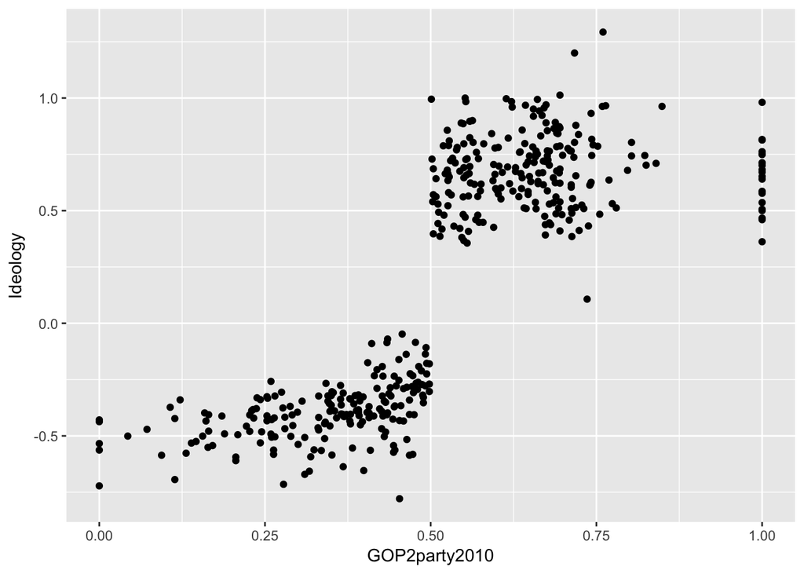

```r
ggplot (data=CongressRD, mapping=aes(x=GOP2party2010, y=Ideology)) +
  geom_point()
```

In the plot, we observe that there is discontinuity of ideology at the 50 percent cutoffpoint. This RD might indicate that congressional members might hold different ideology than non-members, regardless of the party membership.

4. The original basic RD model could be written as: $y_{i} = \beta_0 + \beta_1 T_{i} + \beta_2(x_{i}-C) + \epsilon_{i}$ where $T_i$=1 if $X_{1i}\ge C$ $T_i$=0 if $X_{1i}< C$

In this particular question, the model could be written as $Ideology_{i} = \beta_0 + \beta_1 GOPwin2010_{i} + \beta_2(GOP2party2010_{i}-C) + \epsilon_{i}$ where $GOPwin2010_i$=1 if $X_{1i}\ge C$ $GOPwin2010_i$=0 if $X_{1i}< C$

In this expression, $GOPwin2010_i$ is the dummy variable indicating whether the Republican congressional candidate i has received the treatment (i.e. win the election). $GOP2party2010_{i}-C$ is our assignment variable, which indicates how much above or below the cutoff an observation is. C is the cutoff and $C=0.5$ in this particular model. $\beta_1$ is the estimate of the treatment effect. $\beta_2$ is the slope parameter, capturing the relationship between the distance to the cutoff variable and the dependent varaible.

```r
CongressRD$cutoff<-0.5
CongressRD$Assign<- CongressRD$GOP2party2010-CongressRD$cutoff
reg113e<- lm(Ideology~GOPwin2010 + Assign , data=CongressRD)
summary(reg113e)
```

```
##
## Call:
## lm(formula = Ideology ~ GOPwin2010 + Assign, data = CongressRD)
##
## Residuals:
##      Min       1Q   Median       3Q      Max
## -0.58267 -0.08808  0.00127  0.08758  0.59780
##
## Coefficients:
##             Estimate Std. Error t value Pr(>|t|)
## (Intercept) -0.35989    0.01410 -25.531  < 2e-16 ***
## GOPwin2010   0.99517    0.02382  41.788  < 2e-16 ***
## Assign       0.23044    0.05711   4.035 6.46e-05 ***
## ---
## Signif. codes:  0 '***' 0.001 '**' 0.01 '*' 0.05 '.' 0.1 ' ' 1
##
## Residual standard error: 0.1511 on 429 degrees of freedom
##   (13 observations deleted due to missingness)
## Multiple R-squared:  0.926,  Adjusted R-squared:  0.9257
## F-statistic:  2686 on 2 and 429 DF,  p-value: < 2.2e-16
```

In the results, we focus on the coefficient of GOPwin2010, as the $\beta_1$ in the model. It suggests that the treatment (i.e. winning the congressional election) generate an increase in ideology by 0.99517 (i.e. the bump/ the discontinuity). P value <0.05 suggesting the result is statistically significant. $\beta_2$ = 0.23044, suggesting the 1 unit away from the cutoff point, the ideology will change by 0.23044.

```r
CongressRD$AssignT<- CongressRD$Assign*CongressRD$GOPwin2010
reg113f<-  lm(Ideology~GOPwin2010 + Assign+AssignT , data=CongressRD)
summary (reg113f)
```

```
##
## Call:
## lm(formula = Ideology ~ GOPwin2010 + Assign + AssignT, data = CongressRD)
##
## Residuals:
##      Min       1Q   Median       3Q      Max
## -0.57056 -0.08642  0.00080  0.08801  0.61449
##
## Coefficients:
##             Estimate Std. Error t value Pr(>|t|)
## (Intercept) -0.31327    0.01762 -17.776  < 2e-16 ***
## GOPwin2010   0.98157    0.02357  41.646  < 2e-16 ***
## Assign       0.52861    0.08959   5.900 7.39e-09 ***
## AssignT     -0.48933    0.11477  -4.263 2.48e-05 ***
## ---
## Signif. codes:  0 '***' 0.001 '**' 0.01 '*' 0.05 '.' 0.1 ' ' 1
##
## Residual standard error: 0.1482 on 428 degrees of freedom
##   (13 observations deleted due to missingness)
## Multiple R-squared:  0.9291, Adjusted R-squared:  0.9286
## F-statistic:  1868 on 3 and 428 DF,  p-value: < 2.2e-16
```

- In the result, the coefficient for GOPwin2010 is the average treatment effect - winning election increases ideology score by 0.9816. The coefficient for Assign (0.52861) is the slope for untreated observations (left of the cutoff), the coefficient for AssignT (-0.48933) is the difference between the slop of trated and untreated group, and the slope for the treated observations (to the right of the cutoff) is the sum of the two coeffcient of Assign an AssignT = 0.52861-0.48933= 0.03928.

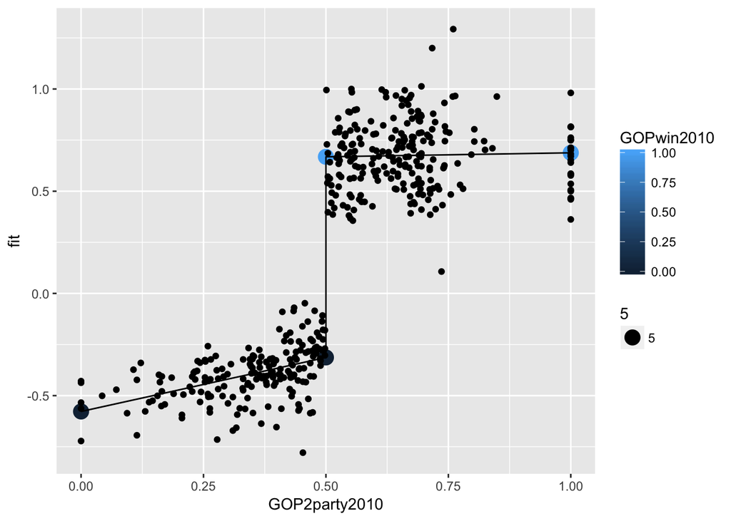

```r
GOP2party2010=c(0, 0.5, 0.5, 1.0)
GOPwin2010= c(0, 0 , 1, 1)
Assign<- c(-0.5, 0, 0, 0.5)
AssignT<- c(0, 0, 0, 0.5)
newdata113f<- data_frame(GOP2party2010,GOPwin2010, Assign, AssignT)
predict113f <- predict (reg113f, newdata = newdata113f, interval="predict")
plot113f<- cbind (newdata113f, predict113f)

ggplot()+
  geom_point(data=plot113f, mapping= aes(x=GOP2party2010, y=fit, color=GOPwin2010, size=5)) +
  geom_point(data=CongressRD, mapping= aes( x=GOP2party2010, y=Ideology))+
  geom_line(data=plot113f, mapping= aes(x=GOP2party2010, y=fit))
```

7. Here I am unsure what is the unadjusted variable. I assume it is $X_i$ without deduction of $C$. But it is confusing for me how to deal with it without adjustment..

```r
CongressRD$AssignT2<- CongressRD$GOP2party2010* CongressRD$GOPwin2010
reg113g<- lm(Ideology~GOPwin2010 + GOP2party2010 +AssignT2 , data=CongressRD)
summary(reg113g)
```

```
##
## Call:
## lm(formula = Ideology ~ GOPwin2010 + GOP2party2010 + AssignT2,
##     data = CongressRD)
##
## Residuals:
##      Min       1Q   Median       3Q      Max
## -0.57056 -0.08642  0.00080  0.08801  0.61449
##
## Coefficients:
##               Estimate Std. Error t value Pr(>|t|)
## (Intercept)   -0.57758    0.03259 -17.720  < 2e-16 ***
## GOPwin2010     1.22623    0.05901  20.779  < 2e-16 ***
## GOP2party2010  0.52861    0.08959   5.900 7.39e-09 ***
## AssignT2      -0.48933    0.11477  -4.263 2.48e-05 ***
## ---
## Signif. codes:  0 '***' 0.001 '**' 0.01 '*' 0.05 '.' 0.1 ' ' 1
##
## Residual standard error: 0.1482 on 428 degrees of freedom
##   (13 observations deleted due to missingness)
## Multiple R-squared:  0.9291, Adjusted R-squared:  0.9286
## F-statistic:  1868 on 3 and 428 DF,  p-value: < 2.2e-16
```

```r
GOP2party2010=c(0, 0.5, 0.5, 1.0)
GOPwin2010= c(0, 0, 1, 1)
AssignT2<- c(0,0, 0.5, 1)
newdata113g<- data_frame(GOP2party2010,GOPwin2010, AssignT2)
predict113g <- predict (reg113g, newdata = newdata113g, interval="predict")
predict113g
```

```
##          fit        lwr         upr
## 1 -0.5775762 -0.8758422 -0.27931017
## 2 -0.3132725 -0.6066290 -0.01991599
## 3  0.6682932  0.3753693  0.96121714
## 4  0.6879330  0.3923959  0.98347014
```

In comparison to the fitted value in question (f), the fitted values are the same.

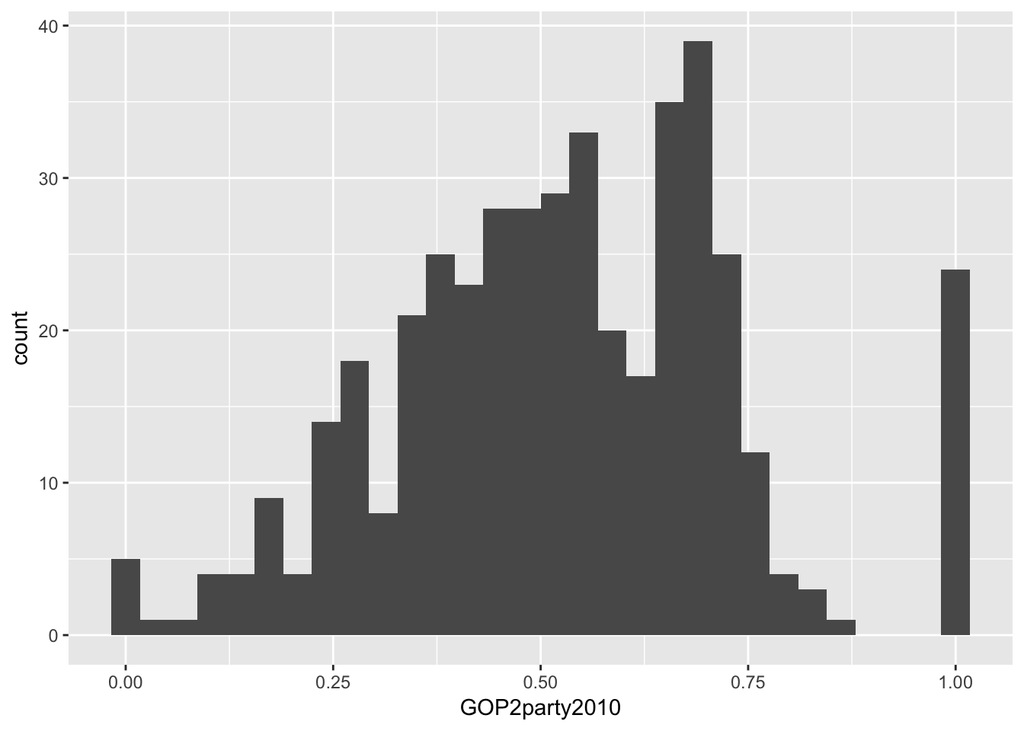

```r
ggplot (data=CongressRD) +
  geom_histogram (aes(x=GOP2party2010))
```

Based on the histogram, one could notice that the number of assignment variables are almost the same on the left and right sight of the cutoff of 0.5, suggesting there is not clustering of the dependent variable just above the cutoff.

```r
reg113i_1<- lm(data=CongressRD, ChildPoverty~GOPwin2010 + Assign)
summary(reg113i_1)
```

```
##
## Call:
## lm(formula = ChildPoverty ~ GOPwin2010 + Assign, data = CongressRD)
##
## Residuals:
##       Min        1Q    Median        3Q       Max
## -0.184529 -0.062279  0.000092  0.050682  0.237495
##
## Coefficients:
##              Estimate Std. Error t value Pr(>|t|)
## (Intercept)  0.207860   0.007465  27.846  < 2e-16 ***
## GOPwin2010  -0.012161   0.012624  -0.963  0.33593
## Assign      -0.097691   0.030316  -3.222  0.00137 **
## ---
## Signif. codes:  0 '***' 0.001 '**' 0.01 '*' 0.05 '.' 0.1 ' ' 1
##
## Residual standard error: 0.08038 on 432 degrees of freedom
##   (10 observations deleted due to missingness)
## Multiple R-squared:  0.09039,    Adjusted R-squared:  0.08618
## F-statistic: 21.46 on 2 and 432 DF,  p-value: 1.296e-09
```

```r
reg113i_2<- lm(data=CongressRD, MedianIncome~GOPwin2010 + Assign)
summary(reg113i_2)
```

```
##
## Call:
## lm(formula = MedianIncome ~ GOPwin2010 + Assign, data = CongressRD)
##
## Residuals:
##    Min     1Q Median     3Q    Max
## -27693  -9811  -2648   6883  51351
##
## Coefficients:
##             Estimate Std. Error t value Pr(>|t|)
## (Intercept)  52318.7     1273.5  41.083   <2e-16 ***
## GOPwin2010    -388.1     2153.7  -0.180    0.857
## Assign        2920.1     5171.9   0.565    0.573
## ---
## Signif. codes:  0 '***' 0.001 '**' 0.01 '*' 0.05 '.' 0.1 ' ' 1
##
## Residual standard error: 13710 on 432 degrees of freedom
##   (10 observations deleted due to missingness)
## Multiple R-squared:  0.001168,   Adjusted R-squared:  -0.003456
## F-statistic: 0.2525 on 2 and 432 DF,  p-value: 0.7769
```

```r
reg113i_3<- lm(data=CongressRD, Obama2008~GOPwin2010 + Assign)
summary(reg113i_3)
```

```
##
## Call:
## lm(formula = Obama2008 ~ GOPwin2010 + Assign, data = CongressRD)
##
## Residuals:
##       Min        1Q    Median        3Q       Max
## -0.272581 -0.042540 -0.001066  0.036882  0.232936
##
## Coefficients:
##              Estimate Std. Error t value Pr(>|t|)
## (Intercept)  0.576674   0.006244  92.351  < 2e-16 ***
## GOPwin2010  -0.043398   0.010561  -4.109 4.75e-05 ***
## Assign      -0.552423   0.025360 -21.783  < 2e-16 ***
## ---
## Signif. codes:  0 '***' 0.001 '**' 0.01 '*' 0.05 '.' 0.1 ' ' 1
##
## Residual standard error: 0.06724 on 432 degrees of freedom
##   (10 observations deleted due to missingness)
## Multiple R-squared:  0.795,  Adjusted R-squared:  0.7941
## F-statistic: 837.7 on 2 and 432 DF,  p-value: < 2.2e-16
```

```r
reg113i_4<- lm(data=CongressRD, WhitePct~GOPwin2010 + Assign)
summary(reg113i_4)
```

```
##
## Call:
## lm(formula = WhitePct ~ GOPwin2010 + Assign, data = CongressRD)
##
## Residuals:
##     Min      1Q  Median      3Q     Max
## -0.7419 -0.1363  0.0322  0.1407  0.3980
##
## Coefficients:
##             Estimate Std. Error t value Pr(>|t|)
## (Intercept)  0.64543    0.01762  36.621  < 2e-16 ***
## GOPwin2010   0.05953    0.02981   1.997   0.0464 *
## Assign       0.49384    0.07158   6.899 1.87e-11 ***
## ---
## Signif. codes:  0 '***' 0.001 '**' 0.01 '*' 0.05 '.' 0.1 ' ' 1
##
## Residual standard error: 0.1898 on 432 degrees of freedom
##   (10 observations deleted due to missingness)
## Multiple R-squared:  0.3101, Adjusted R-squared:  0.3069
## F-statistic:  97.1 on 2 and 432 DF,  p-value: < 2.2e-16
```

Among the four results, neither ChildPverty nor MedianIncome display significant discontinuities at the cutoff point. Obama2008 has a statistically significant negative effect on ideology of congress members, but the coefficient is only -0.043398. So the result is relatively negligible. The same pattern could be observed in the case of WhitePct (statisticly significant effects but limited in magnitude). So we might suggest both Obama2008 and WhitePct might generate discontinuity at the cutoff.

10. Here I use the adjusted assignment variable, like in question (f).

```r
reg113j<-  lm(Ideology~GOPwin2010 + Assign+AssignT+ChildPoverty+ MedianIncome+ Obama2008+ WhitePct, data=CongressRD)
summary (reg113j)
```

```
##
## Call:
## lm(formula = Ideology ~ GOPwin2010 + Assign + AssignT + ChildPoverty +
##     MedianIncome + Obama2008 + WhitePct, data = CongressRD)
##
## Residuals:
##      Min       1Q   Median       3Q      Max
## -0.59328 -0.08678  0.00749  0.08586  0.54675
##
## Coefficients:
##                Estimate Std. Error t value Pr(>|t|)
## (Intercept)  -1.341e-02  1.272e-01  -0.105   0.9161
## GOPwin2010    9.628e-01  2.287e-02  42.099  < 2e-16 ***
## Assign       -4.762e-02  1.417e-01  -0.336   0.7369
## AssignT      -1.771e-01  1.366e-01  -1.297   0.1955
## ChildPoverty  2.651e-01  1.885e-01   1.406   0.1604
## MedianIncome  2.121e-06  1.009e-06   2.103   0.0361 *
## Obama2008    -7.905e-01  1.243e-01  -6.362 5.16e-10 ***
## WhitePct     -6.086e-02  4.978e-02  -1.223   0.2222
## ---
## Signif. codes:  0 '***' 0.001 '**' 0.01 '*' 0.05 '.' 0.1 ' ' 1
##
## Residual standard error: 0.1419 on 424 degrees of freedom
##   (13 observations deleted due to missingness)
## Multiple R-squared:  0.9356, Adjusted R-squared:  0.9345
## F-statistic: 879.6 on 7 and 424 DF,  p-value: < 2.2e-16
```

Like in question (i), this serves as a balance tests for disgnosing whether other variables also generate discontinuity at cutoff point and might challenge the main assumption of the RD model. Here we find that Obama2008 still have negative and statistically significant effect (i.e. discontinuity). Since the data is from 2010, after Obama was elected, it seems plausible that the ideology of congress be influenced by the presidential election result. Meanwhile, while MedianIncome was not statistically significant in past test, it now displays significant discontinuity.

```r
CongressRD$Assign2<- CongressRD$Assign^2
reg113k<-  lm(Ideology~GOPwin2010 + Assign+ Assign2 , data=CongressRD)
summary (reg113k)
```

```
##
## Call:
## lm(formula = Ideology ~ GOPwin2010 + Assign + Assign2, data = CongressRD)
##
## Residuals:
##      Min       1Q   Median       3Q      Max
## -0.58318 -0.08551  0.00257  0.08152  0.60160
##
## Coefficients:
##             Estimate Std. Error t value Pr(>|t|)
## (Intercept) -0.32876    0.01553 -21.174  < 2e-16 ***
## GOPwin2010   0.97566    0.02375  41.085  < 2e-16 ***
## Assign       0.30354    0.05837   5.200 3.09e-07 ***
## Assign2     -0.50902    0.11620  -4.381 1.49e-05 ***
## ---
## Signif. codes:  0 '***' 0.001 '**' 0.01 '*' 0.05 '.' 0.1 ' ' 1
##
## Residual standard error: 0.148 on 428 degrees of freedom
##   (13 observations deleted due to missingness)
## Multiple R-squared:  0.9292, Adjusted R-squared:  0.9287
## F-statistic:  1873 on 3 and 428 DF,  p-value: < 2.2e-16
```

The results indicates that on average GOPwin2010 has a positive and significant effect on ideology. The coefficient for GOPwin2010 is very similar to the previous ones in basic RD model (question e) and varying slopes RD model (question f).

```r
CongressRD_l<- filter (CongressRD, GOP2party2010<=0.6 & GOP2party2010>=0.4)
reg113l<-  lm(Ideology~GOPwin2010 + Assign+ AssignT , data=CongressRD_l)
summary(reg113l)
```

```
##
## Call:
## lm(formula = Ideology ~ GOPwin2010 + Assign + AssignT, data = CongressRD_l)
##
## Residuals:
##      Min       1Q   Median       3Q      Max
## -0.45728 -0.08422  0.00208  0.09514  0.37169
##
## Coefficients:
##             Estimate Std. Error t value Pr(>|t|)
## (Intercept) -0.26987    0.03487  -7.740 1.39e-12 ***
## GOPwin2010   0.89273    0.04893  18.243  < 2e-16 ***
## Assign       1.10321    0.63159   1.747   0.0827 .
## AssignT     -0.64858    0.90614  -0.716   0.4753
## ---
## Signif. codes:  0 '***' 0.001 '**' 0.01 '*' 0.05 '.' 0.1 ' ' 1
##
## Residual standard error: 0.1502 on 149 degrees of freedom
##   (1 observation deleted due to missingness)
## Multiple R-squared:  0.9142, Adjusted R-squared:  0.9125
## F-statistic: 529.1 on 3 and 149 DF,  p-value: < 2.2e-16
```

The coefficient of GOPwin2010 is now smaller, reduced from around 0.98 (in question(f)) to 0.89. Though it remains statistically significant, the standard error has doubled from 0.024 to 0.048. Meanwhile, the coefficient of Assignment variable and interaction both changes: the standard error increases substantially so neither remain statistically significant. But we notice that the direction of correlation (i.e. positive or negative) has not changed. This might be caused by the reduction of the number of observations (i.e. sample size).

13. I think none of the model is perfect. But the one in question (j) works well as it uses varying slope RD model and accounts for other potential discontinuity. It could be improved if one applies window strategy with it.

### Bailey 11.4

```r
LM<- read_csv("./Data/LudwigMiller_head_start.csv")
```

1. The original basic RD model could be written as: $y_{i} = \beta_0 + \beta_1 T_{i} + \beta_2(x_{i}-C) + \epsilon_{i}$ where $T_i$=1 if $X_{1i}\ge C$ $T_i$=0 if $X_{1i}< C$

Here the model should be $Mortality_{i} = \beta_0 + \beta_1 HeadStart_{i} + \beta_2Poverty_{i} + \epsilon_{i}$ where $HeadStart_i$=1 if $Poverty_{i}>0$ $HeadStart_i$=0 if $Poverty_{i}\leq 0$

Since the Poverty variable has been transfored by subtracting cutoff and divided by 10, we no longer need C (for cutoff) here.

I expect to find that at the cutoff point of poverty, there displays a discontinuity (drop) of mortality. To the right of the cutoff point, the mortality rate could be much lower than the rate on the left.

2. RD could identify a causal effect of Head Start assistance as we assume the counties with poverty close to 59.2 percent is basically the same so the treatment could be seen as randomly assigned. In this way, if we identify discontinuity at the cutoff point, we could identify there exists causality.

```r
reg114c<- lm(Mortality~HeadStart+ Poverty, data=LM)
summary (reg114c)
```

```
##
## Call:
## lm(formula = Mortality ~ HeadStart + Poverty, data = LM)
##
## Residuals:
##     Min      1Q  Median      3Q     Max
##  -3.107  -2.304  -1.801   0.719 133.839
##
## Coefficients:
##             Estimate Std. Error t value Pr(>|t|)
## (Intercept)  3.10947    0.24385  12.752  < 2e-16 ***
## HeadStart   -0.91310    0.43366  -2.106   0.0353 *
## Poverty      0.33767    0.07791   4.334 1.51e-05 ***
## ---
## Signif. codes:  0 '***' 0.001 '**' 0.01 '*' 0.05 '.' 0.1 ' ' 1
##
## Residual standard error: 5.502 on 3101 degrees of freedom
##   (5 observations deleted due to missingness)
## Multiple R-squared:  0.006223,   Adjusted R-squared:  0.005582
## F-statistic:  9.71 on 2 and 3101 DF,  p-value: 6.257e-05
```

The results suggests that HeadStart assistance has a significant effect ($\alpha= 0.05$) on reducing mortality. Poverty has a positive and significant effect on mortality.

```r
LM$PovertyT<- LM$Poverty* LM$HeadStart
reg114d<- lm(data=LM, Mortality~ HeadStart+ Poverty+ PovertyT)
summary(reg114d)
```

```
##
## Call:
## lm(formula = Mortality ~ HeadStart + Poverty + PovertyT, data = LM)
##
## Residuals:
##     Min      1Q  Median      3Q     Max
##  -3.240  -2.285  -1.804   0.715 133.840
##
## Coefficients:
##             Estimate Std. Error t value Pr(>|t|)
## (Intercept)  3.10090    0.24553  12.630  < 2e-16 ***
## HeadStart   -1.02678    0.57416  -1.788   0.0738 .
## Poverty      0.33465    0.07856   4.260 2.11e-05 ***
## PovertyT     0.18632    0.61663   0.302   0.7626
## ---
## Signif. codes:  0 '***' 0.001 '**' 0.01 '*' 0.05 '.' 0.1 ' ' 1
##
## Residual standard error: 5.503 on 3100 degrees of freedom
##   (5 observations deleted due to missingness)
## Multiple R-squared:  0.006252,   Adjusted R-squared:  0.005291
## F-statistic: 6.502 on 3 and 3100 DF,  p-value: 0.000221
```

The effects of HeadStart Assistance is magnified but the significance level has decreased. Poverty still has a positive and significant effect on mortality.

```r
LM_e<- filter (LM, Poverty<=0.8 & Poverty>=-0.8)
reg114e<- lm(data=LM_e, Mortality~ HeadStart+ Poverty)
summary(reg114e)
```

```
##
## Call:
## lm(formula = Mortality ~ HeadStart + Poverty, data = LM_e)
##
## Residuals:
##    Min     1Q Median     3Q    Max
## -3.773 -2.886 -2.354  1.857 61.507
##
## Coefficients:
##             Estimate Std. Error t value Pr(>|t|)
## (Intercept)   3.7858     0.5606   6.753  4.2e-11 ***
## HeadStart    -2.1035     0.9961  -2.112   0.0352 *
## Poverty       1.8408     1.0945   1.682   0.0932 .
## ---
## Signif. codes:  0 '***' 0.001 '**' 0.01 '*' 0.05 '.' 0.1 ' ' 1
##
## Residual standard error: 5.477 on 479 degrees of freedom
## Multiple R-squared:  0.009376,   Adjusted R-squared:  0.00524
## F-statistic: 2.267 on 2 and 479 DF,  p-value: 0.1048
```

Here we find the effect of HeadStart has been increased and become statistically significant at the significance level of $\alpha=0.05$. Yet the effect of Poverty has become less significant. The standar error both increase and this might due to our narrowing down the window hence reduce the sample size.

```r
LM$Poverty2<- LM$Poverty^2
reg114f<- lm(data=LM, Mortality~ HeadStart+ Poverty+ Poverty2)
summary(reg114f)
```

```
##
## Call:
## lm(formula = Mortality ~ HeadStart + Poverty + Poverty2, data = LM)
##
## Residuals:
##     Min      1Q  Median      3Q     Max
##  -3.393  -2.234  -1.799   0.676 133.905
##
## Coefficients:
##             Estimate Std. Error t value Pr(>|t|)
## (Intercept)  3.27692    0.33257   9.853   <2e-16 ***
## HeadStart   -1.22854    0.60790  -2.021   0.0434 *
## Poverty      0.52077    0.25923   2.009   0.0446 *
## Poverty2     0.03595    0.04854   0.741   0.4590
## ---
## Signif. codes:  0 '***' 0.001 '**' 0.01 '*' 0.05 '.' 0.1 ' ' 1
##
## Residual standard error: 5.502 on 3100 degrees of freedom
##   (5 observations deleted due to missingness)
## Multiple R-squared:  0.006399,   Adjusted R-squared:  0.005437
## F-statistic: 6.655 on 3 and 3100 DF,  p-value: 0.0001777
```

The results also supports the negative and significant effect of the HeadStart Program in mortality. Poverty remains positively correlated with Mortality.

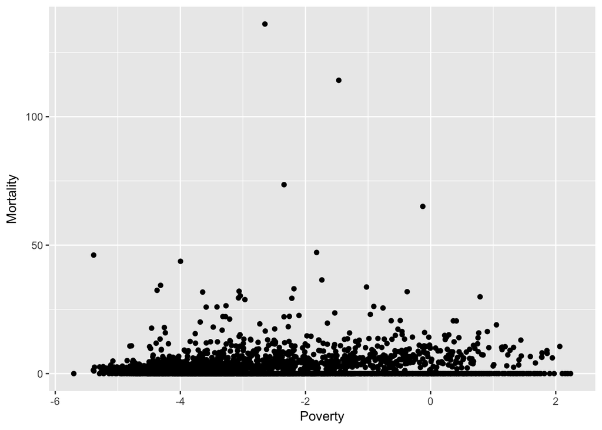

```r
ggplot (data=LM, mapping = aes (x=Poverty, y= Mortality)) + geom_point()
```

There are some outlier countries with extremely high Mortality and this is biasing both the plot itself and the results. It is hard to view if there exists any discontinuity on this plot. We problably should remove these outliers.

8. The book only provides Stata cold, so I try to plot it with a R package ‘rdrobust’.

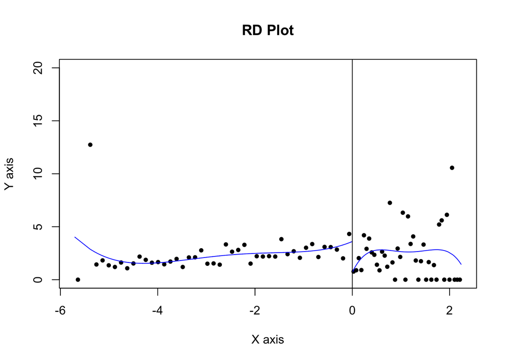

```r
rdplot(y=LM$Mortality, x= LM$Poverty, c=0, y.lim = c(0,20))
```

Clearly there is discontuinity at the cutoff point of 0.

### Bailey 13.3

```r
Bond<-read_csv("./Data/BondUpdate.csv")
```

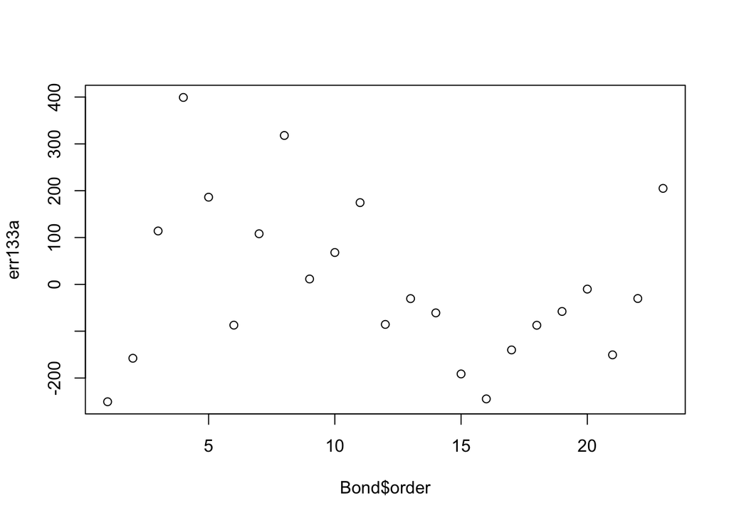

```r
reg133a<- lm(data=Bond, GrossRev~ Budget+ Rating)
err133a<- resid(reg133a)
plot(Bond$order, err133a)
```

```r
LagErr133a<- c(NA, err133a[1:(length(err133a)-1)])
LagErrOLS133a<- lm(err133a~LagErr133a)
summary (LagErrOLS133a)
```

```
##
## Call:
## lm(formula = err133a ~ LagErr133a)
##
## Residuals:
##     Min      1Q  Median      3Q     Max
## -184.49 -123.64  -21.64  108.74  333.53
##
## Coefficients:
##             Estimate Std. Error t value Pr(>|t|)
## (Intercept)  15.4928    32.7731   0.473   0.6415
## LagErr133a    0.4398     0.1963   2.240   0.0366 *
## ---
## Signif. codes:  0 '***' 0.001 '**' 0.01 '*' 0.05 '.' 0.1 ' ' 1
##
## Residual standard error: 153.5 on 20 degrees of freedom
##   (1 observation deleted due to missingness)
## Multiple R-squared:  0.2005, Adjusted R-squared:  0.1606
## F-statistic: 5.017 on 1 and 20 DF,  p-value: 0.03662
```

First we look at the plot, it is not very smooth. Then we look at the coefficient of LagErr (i.e.$\hat \rho$ estimate). It is 0.4398, which is a quite strong relation. The standard error is 0.196 and the P value is 0.0366<0.05. Hence we could reject the null hypothesis that $\rho=0$ and conclude that the errors are autocorrelated.

```r
Rho<- summary (LagErrOLS133a)$coefficients[2]
N= length (Bond$GrossRev)
LagGrossRev<- c(NA, Bond$GrossRev[1:(N-1)])
LagBudget <- c(NA, Bond$Budget[1:(N-1)])
LagRating<- c(NA, Bond$Rating[1:(N-1)])
GrossRevRho<- mean(Bond$GrossRev)- Rho*LagGrossRev
BudgetRho<- Bond$Budget-Rho*LagBudget
RatingRho<- Bond$Rating-Rho*LagRating
reg133b<-lm (GrossRevRho~ BudgetRho+RatingRho)
summary(reg133b)
```

```
##
## Call:
## lm(formula = GrossRevRho ~ BudgetRho + RatingRho)
##
## Residuals:
##      Min       1Q   Median       3Q      Max
## -189.286  -43.174    4.178   47.662  117.082
##
## Coefficients:
##             Estimate Std. Error t value Pr(>|t|)
## (Intercept) 248.2268   111.9186   2.218   0.0389 *
## BudgetRho     0.1770     0.4272   0.414   0.6832
## RatingRho    26.0717    27.1912   0.959   0.3497
## ---
## Signif. codes:  0 '***' 0.001 '**' 0.01 '*' 0.05 '.' 0.1 ' ' 1
##
## Residual standard error: 85.22 on 19 degrees of freedom
##   (1 observation deleted due to missingness)
## Multiple R-squared:  0.04723,    Adjusted R-squared:  -0.05307
## F-statistic: 0.4709 on 2 and 19 DF,  p-value: 0.6315
```

The result does change. Now $\rho$ estimates is no longer statisticaly significant.

```r
reg133c<- lm(data=Bond, GrossRev~ Budget+ LagGrossRev)
summary (reg133c)
```

```
##
## Call:
## lm(formula = GrossRev ~ Budget + LagGrossRev, data = Bond)
##
## Residuals:
##     Min      1Q  Median      3Q     Max
## -286.60 -125.16  -62.94   97.34  436.96
##
## Coefficients:
##             Estimate Std. Error t value Pr(>|t|)
## (Intercept) 259.9036   160.2931   1.621   0.1214
## Budget        0.3234     0.6801   0.476   0.6398
## LagGrossRev   0.5622     0.2303   2.441   0.0246 *
## ---
## Signif. codes:  0 '***' 0.001 '**' 0.01 '*' 0.05 '.' 0.1 ' ' 1
##
## Residual standard error: 198.7 on 19 degrees of freedom
##   (1 observation deleted due to missingness)
## Multiple R-squared:  0.2414, Adjusted R-squared:  0.1615
## F-statistic: 3.023 on 2 and 19 DF,  p-value: 0.07247
```

The short-term effect is indicated by $_1 = 0.3234 $. The long-term effect is $\frac{\beta_1}{1-\gamma}= \frac{0.3234}{1-0.5622}= 0.73869$

4. I am using the R package “tseries” to work out the stationarity.

```r
adf.test(Bond$GrossRev, alternative = "stationary") # revenue
```

```
##
##  Augmented Dickey-Fuller Test
##
## data:  Bond$GrossRev
## Dickey-Fuller = -0.25507, Lag order = 2, p-value = 0.9855
## alternative hypothesis: stationary
```

P-value=0.9855, hence not significant, it’s not stationary.

```r
adf.test(Bond$Rating, alternative = "stationary") # rating
```

```
##
##  Augmented Dickey-Fuller Test
##
## data:  Bond$Rating
## Dickey-Fuller = -1.6962, Lag order = 2, p-value = 0.6881
## alternative hypothesis: stationary
```

P-value-0.6881 > 0.05

```r
adf.test(Bond$Budget, alternative = "stationary") # budget
```

```
##
##  Augmented Dickey-Fuller Test
##
## data:  Bond$Budget
## Dickey-Fuller = -1.5012, Lag order = 2, p-value = 0.7624
## alternative hypothesis: stationary
```

P-value =0.7624>0.05 - None of the variables is stationary.

```r
DiffBudget<- diff(Bond$Budget)
DiffRev<-diff(Bond$GrossRev)
DiffRating<- diff(Bond$Rating)
reg133e<-lm(DiffRev~DiffBudget+DiffRating)
summary(reg133e)
```

```
##
## Call:
## lm(formula = DiffRev ~ DiffBudget + DiffRating)
##
## Residuals:
##     Min      1Q  Median      3Q     Max
## -298.66  -72.69  -10.58   71.97  273.06
##
## Coefficients:
##             Estimate Std. Error t value Pr(>|t|)
## (Intercept)    6.175     40.118   0.154  0.87930
## DiffBudget     2.219      1.357   1.636  0.11832
## DiffRating   190.816     62.803   3.038  0.00676 **
## ---
## Signif. codes:  0 '***' 0.001 '**' 0.01 '*' 0.05 '.' 0.1 ' ' 1
##
## Residual standard error: 178 on 19 degrees of freedom
## Multiple R-squared:  0.3374, Adjusted R-squared:  0.2677
## F-statistic: 4.838 on 2 and 19 DF,  p-value: 0.02003
```

The results suggests that rating has strong and significant effect on the box office revenue of the movie. The effect is 190.816 an the P-value is 0.00676<$\alpha=0.01$. On the other hand, budget does not have significant effects.

```r
#1 solution, using factor
Bond_f1<- filter (Bond,order!="1")
reg133f1<- lm(DiffRev~DiffBudget+ DiffRating+ factor(Actor), data=Bond_f1)
summary(reg133f1)
```

```
##
## Call:
## lm(formula = DiffRev ~ DiffBudget + DiffRating + factor(Actor),
##     data = Bond_f1)
##
## Residuals:
##     Min      1Q  Median      3Q     Max
## -324.92  -59.04   15.29   93.34  244.51
##
## Coefficients:
##                      Estimate Std. Error t value Pr(>|t|)
## (Intercept)            25.299     95.394   0.265   0.7947
## DiffBudget              1.930      1.519   1.271   0.2244
## DiffRating            190.603     73.059   2.609   0.0206 *
## factor(Actor)Connery   92.425    123.268   0.750   0.4658
## factor(Actor)Craig     26.441    138.655   0.191   0.8515
## factor(Actor)Dalton  -133.429    153.837  -0.867   0.4004
## factor(Actor)Lazenby -281.112    203.586  -1.381   0.1890
## factor(Actor)Moore    -51.127    117.389  -0.436   0.6698
## ---
## Signif. codes:  0 '***' 0.001 '**' 0.01 '*' 0.05 '.' 0.1 ' ' 1
##
## Residual standard error: 175.8 on 14 degrees of freedom
## Multiple R-squared:  0.5235, Adjusted R-squared:  0.2852
## F-statistic: 2.197 on 7 and 14 DF,  p-value: 0.09952
```

```r
#2 solution is using a differenced model by assigning numeric indicators to each actor
actor<-c(1,1,1,1,1,2,1,3,3,3,3,3,3,3,4,4,5,5,5,5,6,6,6)
Bond_f2<-cbind (Bond,actor)
Diffactor<-diff(Bond_f2$actor)
reg133f2<- lm(DiffRev~DiffBudget+ DiffRating+ Diffactor, data=Bond_f2)
summary (reg133f2)
```

```
##
## Call:
## lm(formula = DiffRev ~ DiffBudget + DiffRating + Diffactor, data = Bond_f2)
##
## Residuals:
##     Min      1Q  Median      3Q     Max
## -301.39  -65.83  -22.44   79.34  274.87
##
## Coefficients:
##             Estimate Std. Error t value Pr(>|t|)
## (Intercept)   13.146     43.422   0.303  0.76556
## DiffBudget     2.261      1.388   1.629  0.12061
## DiffRating   199.902     66.813   2.992  0.00782 **
## Diffactor    -33.194     68.725  -0.483  0.63492
## ---
## Signif. codes:  0 '***' 0.001 '**' 0.01 '*' 0.05 '.' 0.1 ' ' 1
##
## Residual standard error: 181.7 on 18 degrees of freedom
## Multiple R-squared:  0.3459, Adjusted R-squared:  0.2369
## F-statistic: 3.173 on 3 and 18 DF,  p-value: 0.04942
```

Both results suggest that changing actor does not have significant effect on the revenue.

### Bailey 15.1

```r
Olympics<- read_csv("./Data/olympics_HW.csv")
reg151a<- lm(medals~population+GDP+host+temp+elevation+factor(country), data=Olympics)
tidy(reg151a) %>%
  filter(term %in% c("population","GDP","host","temp","elevation"))
```

```
##         term      estimate   std.error     statistic      p.value
## 1 population  1.282955e-02 0.003562288  3.6014925577 3.349234e-04
## 2        GDP  8.165972e-01 0.097428385  8.3815117778 2.179863e-16
## 3       host  5.764501e+00 0.995971671  5.7878166770 1.005715e-08
## 4       temp -3.118156e-05 0.051439845 -0.0006061753 9.995165e-01
## 5  elevation  1.294068e-04 0.004664436  0.0277433021 9.778735e-01
```

The results suggest that the population, GDP and host all have positive and significant effects on the number of medals. The coefficient on elevation suggests that elevation might have positive impact on the number of medals, while the effect is not significant. Lastly, it is interesting to notice that temperature have negative yet insignificant effects on the number of medals. So higher temperature might reduce the competitiveness of athlets?

```r
reg151b<- lm(medals~population+GDP+host+temp+elevation+factor(country)+factor(year), data=Olympics)
tidy(reg151b) %>%
  filter(term %in% c("population","GDP","host","temp","elevation"))
```

```
##         term      estimate   std.error    statistic      p.value
## 1 population  8.559068e-03 0.003765374  2.273098873 2.327410e-02
## 2        GDP  5.946995e-01 0.123413095  4.818771269 1.716232e-06
## 3       host  5.712661e+00 0.991684169  5.760565275 1.179285e-08
## 4       temp  2.749290e-03 0.051263573  0.053630481 9.572424e-01
## 5  elevation -4.205328e-05 0.004649002 -0.009045658 9.927849e-01
```

The results suggest that: after controlling for both the fixed effects of country and year, 1) the effect of population reduces and becomes less significant; 2) The effects of GDP reduces, and the standard error increases but remains statistically significant; 3)The effect of host remains significant and the magnitude has minor changes; 4) The effect of temperature has changed from negative to positive, still not significant 5) The effect of elevation has changed from positive to negative, still not significant

```r
reg151c<- lm(medals~population+GDP+host+temp+elevation+factor(country)+factor(year), data=Olympics)

Olympics_c<- Olympics %>%
  group_by(country) %>%
  arrange(country, year) %>%
  mutate(Resid=NA)

Olympics_c$Resid[as.numeric(names(reg151c$residuals))]<- reg151c$residuals
Olympics_c<- Olympics_c %>%
  group_by(country) %>%
  arrange(country, year) %>%
  mutate (LagResid= lag(Resid))

RhoHat<- lm(Resid~LagResid, data=Olympics_c)
summary(RhoHat)
```

```
##
## Call:
## lm(formula = Resid ~ LagResid, data = Olympics_c)
##
## Residuals:
##     Min      1Q  Median      3Q     Max
## -9.2946 -0.4901 -0.2081  0.2999 16.0472
##
## Coefficients:
##             Estimate Std. Error t value Pr(>|t|)
## (Intercept)  0.01801    0.07352   0.245    0.807
## LagResid     0.50635    0.02901  17.451   <2e-16 ***
## ---
## Signif. codes:  0 '***' 0.001 '**' 0.01 '*' 0.05 '.' 0.1 ' ' 1
##
## Residual standard error: 2.13 on 837 degrees of freedom
##   (283 observations deleted due to missingness)
## Multiple R-squared:  0.2668, Adjusted R-squared:  0.2659
## F-statistic: 304.6 on 1 and 837 DF,  p-value: < 2.2e-16
```

```r
dwt(reg151c)
```

```
##  lag Autocorrelation D-W Statistic p-value
##    1       0.4480332      1.103769       0
##  Alternative hypothesis: rho != 0
```

The $\hat{\rho}$ estimate (0.5064) and the P value (<2e-16) suggest both strong relationship and autocorrelation. Also the dwtest supports the same argument of autocorrelation.

```r
Olympics_d<- Olympics %>%
  group_by(country) %>%
  arrange(country, year) %>%
  mutate (lagmedal=lag(medals), lagpopulation=lag(population), lagGDP=lag(GDP), laghost=lag(host)) %>%
  mutate(RhoHat=RhoHat$coefficients[2])%>%
  mutate (medalrho=medals-RhoHat* lagmedal, populationrho= population- RhoHat* lagpopulation, GDPrho= GDP-RhoHat*lagGDP, hostrho=host-RhoHat* laghost)

reg151d<- plm(medalrho~populationrho+GDPrho+hostrho, index= c("country","year"), data=Olympics_d, effect = "twoways")
```

```
## This series is constant and has been removed: RhoHat
```

```r
summary(reg151d)
```

```
## Twoways effects Within Model
##
## Call:
## plm(formula = medalrho ~ populationrho + GDPrho + hostrho, data = Olympics_d,
##     effect = "twoways", index = c("country", "year"))
##
## Unbalanced Panel: n=110, T=1-9, N=843
##
## Residuals :
##     Min.  1st Qu.   Median  3rd Qu.     Max.
## -11.0000  -0.3160  -0.0676   0.3480  14.1000
##
## Coefficients :
##                Estimate Std. Error t-value  Pr(>|t|)
## populationrho 0.0128317  0.0082949  1.5469   0.12232
## GDPrho        0.3251514  0.1756593  1.8510   0.06457 .
## hostrho       5.6321188  0.7128558  7.9008 1.035e-14 ***
## ---
## Signif. codes:  0 '***' 0.001 '**' 0.01 '*' 0.05 '.' 0.1 ' ' 1
##
## Total Sum of Squares:    3874.3
## Residual Sum of Squares: 3540.9
## R-Squared:      0.086061
## Adj. R-Squared: -0.06584
## F-statistic: 22.6623 on 3 and 722 DF, p-value: 4.9708e-14
```

This should be caused by the correction of autocorrelation, and the model in (d) is a better model.

```r
Olympics_e<-Olympics %>%
  group_by(country) %>%
  arrange(country, year) %>%
  mutate (lagmedal= lag(medals))

reg151e<- plm(medals~ population+ GDP+ host+ lagmedal, index=c("country","year"), data=Olympics_e, effect = "twoways")
summary(reg151e)
```

```
## Twoways effects Within Model
##
## Call:
## plm(formula = medals ~ population + GDP + host + lagmedal, data = Olympics_e,
##     effect = "twoways", index = c("country", "year"))
##
## Unbalanced Panel: n=111, T=1-9, N=883
##
## Residuals :
##     Min.  1st Qu.   Median  3rd Qu.     Max.
## -10.3000  -0.2910  -0.0663   0.3620  14.9000
##
## Coefficients :
##             Estimate Std. Error t-value  Pr(>|t|)
## population 0.0049467  0.0037680  1.3128   0.18964
## GDP        0.2554879  0.1105333  2.3114   0.02108 *
## host       6.1762737  0.8466007  7.2954 7.503e-13 ***
## lagmedal   0.5416217  0.0293678 18.4427 < 2.2e-16 ***
## ---
## Signif. codes:  0 '***' 0.001 '**' 0.01 '*' 0.05 '.' 0.1 ' ' 1
##
## Total Sum of Squares:    5825.7
## Residual Sum of Squares: 3729.9
## R-Squared:      0.35975
## Adj. R-Squared: 0.25697
## F-statistic: 106.759 on 4 and 760 DF, p-value: < 2.22e-16
```

6. So the question asks if model in (e) experience autocorrelation.

```r
resid151f<-c(NA, length(Olympics_e$year))
resid151f[as.numeric(names(reg151e$residuals))]<-reg151e$residuals
Olympics_e<-cbind(Olympics, resid151f)
Olympics_e<- Olympics_e %>%
  group_by(country) %>%
  arrange(country, year) %>%
  mutate(LagResid= lag(resid151f))
reg151f<-lm(resid151f~LagResid, data=Olympics_e)
summary(reg151f)
```

```
##
## Call:
## lm(formula = resid151f ~ LagResid, data = Olympics_e)
##
## Residuals:
##      Min       1Q   Median       3Q      Max
## -12.6242  -0.3324  -0.1057   0.1092  13.4060
##
## Coefficients:
##             Estimate Std. Error t value Pr(>|t|)
## (Intercept)  0.02117    0.07236   0.293     0.77
## LagResid    -0.22632    0.03640  -6.217 8.31e-10 ***
## ---
## Signif. codes:  0 '***' 0.001 '**' 0.01 '*' 0.05 '.' 0.1 ' ' 1
##
## Residual standard error: 2.004 on 765 degrees of freedom
##   (355 observations deleted due to missingness)
## Multiple R-squared:  0.0481, Adjusted R-squared:  0.04686
## F-statistic: 38.66 on 1 and 765 DF,  p-value: 8.31e-10
```

```r
Olympics_g<- Olympics %>%
  group_by(country) %>%
  arrange(country, year) %>%
  mutate (lagmedal=lag(medals), lagpopulation=lag(population), lagGDP=lag(GDP), laghost=lag(host)) %>%
  mutate(RhoHat=RhoHat$coefficients[2])%>%
  mutate (lagmedal2=lag(lagmedal)) %>%
  mutate (medalrho=lagmedal-RhoHat* lagmedal2, populationrho= population- RhoHat* lagpopulation, GDPrho= GDP-RhoHat*lagGDP, hostrho=host-RhoHat* laghost)

reg151g<- lm(data=Olympics_g, medalrho~ populationrho+ GDPrho+ hostrho)
summary(reg151g)
```

```
##
## Call:
## lm(formula = medalrho ~ populationrho + GDPrho + hostrho, data = Olympics_g)
##
## Residuals:
##     Min      1Q  Median      3Q     Max
## -7.6518 -0.9099 -0.4946 -0.3724 24.7894
##
## Coefficients:
##               Estimate Std. Error t value Pr(>|t|)
## (Intercept)   0.330396   0.145500   2.271   0.0234 *
## populationrho 0.003501   0.001140   3.072   0.0022 **
## GDPrho        0.807864   0.105040   7.691  4.5e-14 ***
## hostrho       0.844559   1.020525   0.828   0.4082
## ---
## Signif. codes:  0 '***' 0.001 '**' 0.01 '*' 0.05 '.' 0.1 ' ' 1
##
## Residual standard error: 3.188 on 764 degrees of freedom
##   (354 observations deleted due to missingness)
## Multiple R-squared:  0.07887,    Adjusted R-squared:  0.07526
## F-statistic: 21.81 on 3 and 764 DF,  p-value: 1.475e-13
```

Compare with model (d): The results are completely differnet in terms of significance and magnitude.

8. According to 15.2, when using lagged dependent variable in fixed effects model, we should use robust errors that account for autocorrelation. The potential determinant is de-meaned error term and the time variable. In order to asess this factor, one could subset this dataset to several subgroups and use same specification to test if the coefficient changes or not.
9. I think a lagged dependent variable would work better in this particular case as it involves panel data across 34 years. 1) The relatively long time scope suggests that autocorrelation might die out. And 2) different observations of different states might work differently in terms of autocorrelation (i.e. the effect die out at different rate etc.) So using a dependent variable works better.
10. Robustness means that the statistical result doesn’t change when model changes. Based on this criterion, (b) and (e) are more robust than the others.